# Predicting the Nightly Price of a San Fransisco Airbnb Unit

by Alex Cho

# Introduction

San Francisco is quite the unique city. Given its rich history including the more recent tech boom, there is a lot to unpack regarding its real estate scene. The city is divided into dozens of districts which are extremely diverse in terms of landscape, culture, and most importantly housing prices. Marina for example is home to the most expensive real estate in the city. SoMa (South of Market), dotted with upscale dining options, has seen its home prices gain dramatically in recent years.

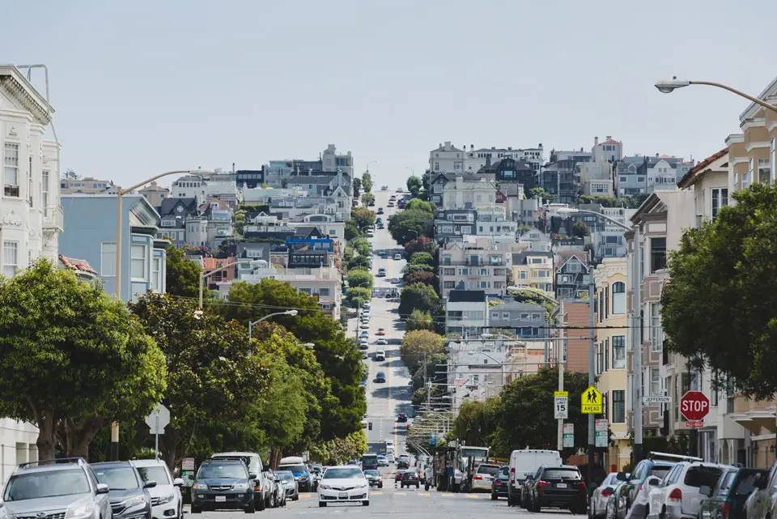

SF Marina District

The purpose of this project is to develop a model that will predict the nightly price of an SF Airbnb unit.

## Objectives

The question I would like to propose throughout this project is “What could we expect to pay for a night at an Airbnb unit in San Francisco given their existing statistics?” Information like district it is located in, number of bedrooms, number of bathrooms, host rating, etc. would seemingly influence the price of the unit. I will be testing to see if a model can be built to predict prices based on this.

This data was taken from Inside Airbnb, http://insideairbnb.com/san-francisco/

# Loading Packages and Data

First we will load in all of the necessary packages and the raw data from an excel file.

```r
library(readxl)
library(tidymodels)
library(tidyverse)
library(ggplot2)
library(corrplot)
library(ggthemes)
library(kableExtra)
library(kknn)
library(yardstick)
library(janitor)
library(dplyr)
library(readr)
library(ISLR)
library(discrim)
library(poissonreg)
library(glmnet)
library(corrr)
library(randomForest)
library(xgboost)
library(rpart.plot)
library(vip)
library(ranger)
library(tidytext)
tidymodels_prefer()
set.seed(7136)
```

```r
# assign the data to a variable
sf_airbnb_excel <- read_excel("sf_airbnb_listings.xlsx", skip = 1, col_names = TRUE)

# calling head to see the first several rows
head(sf_airbnb_excel)
```

```
## # A tibble: 6 × 74
##      id listing_…¹ scrap…² last_…³ name  descr…⁴ neigh…⁵ pictu…⁶ host_id host_…⁷
##   <dbl> <chr>        <dbl> <chr>   <chr> <chr>   <chr>   <chr>     <dbl> <chr>
## 1   958 https://w… 2.02e13 2022-0… Brig… "Pleas… Quiet … https:…    1169 https:…
## 2  5858 https://w… 2.02e13 2022-0… Crea… "<b>Th… I love… https:…    8904 https:…
## 3  7918 https://w… 2.02e13 2022-0… A Fr… "Nice … UCSF c… https:…   21994 https:…
## 4  8142 https://w… 2.02e13 2022-0… Frie… "Nice … N Juda… https:…   21994 https:…
## 5  8339 https://w… 2.02e13 2022-0… Hist… "Pls e… <NA>    https:…   24215 https:…
## 6  8739 https://w… 2.02e13 2022-0… Miss… "Welco… Locate… https:…    7149 https:…
## # … with 64 more variables: host_name <chr>, host_since <chr>,
## #   host_location <chr>, host_about <chr>, host_response_time <chr>,
## #   host_response_rate <chr>, host_acceptance_rate <chr>,
## #   host_is_superhost <chr>, host_thumbnail_url <chr>, host_picture_url <chr>,
## #   host_neighbourhood <chr>, host_listings_count <dbl>,
## #   host_total_listings_count <dbl>, host_verifications <chr>,
## #   host_has_profile_pic <chr>, host_identity_verified <chr>, …
```

# Exploring and Tidying the Raw Data

Here, we will be experimenting with data visualization to see what we are working with.

```r
# calling dim() to see how many rows and columns are in the raw dataset
dim(sf_airbnb_excel)
```

```
## [1] 6444   74
```

## Variable Selection

Variables such as listing_url and picture_url among some others are the obvious ones that do not appear to be relevant for price prediction. The column neighbourhood_group_cleansed is completely empty throughout the entire dataset so we will also remove it. There are numerous other qualitative predictors that merely describe the hosts background and other trivial information.

Here is the step to do this.

```r
# selecting the columns that we want
keep_columns <- c("host_response_time", "host_response_rate", "host_acceptance_rate", "host_is_superhost", "host_verifications", "host_identity_verified", "neighbourhood_cleansed", "bedrooms", "price", "availability_30", "number_of_reviews", "review_scores_rating", "instant_bookable", "reviews_per_month")

sf_airbnb_columns_kept <- subset(sf_airbnb_excel, select = keep_columns)
```

## Tidying the Outcome

Quite a few of our selected variables are character variables which is not what we want. For example, host_response_rate and host_acceptance_rate are percentage points out of a 100% but listed as a string. Some of the predictors also have True/False responses which we will have to convert into factors later on.

```r
# changing categorical and character variables to factors
sf_airbnb_columns_kept$host_response_time <- as.factor(sf_airbnb_columns_kept$host_response_time)
sf_airbnb_columns_kept$host_response_rate <- as.factor(sub("%", "", sf_airbnb_columns_kept$host_response_rate, fixed=TRUE))
sf_airbnb_columns_kept$host_acceptance_rate <- as.factor(sf_airbnb_columns_kept$host_acceptance_rate)
sf_airbnb_columns_kept$host_is_superhost <- as.factor(sf_airbnb_columns_kept$host_is_superhost)
sf_airbnb_columns_kept$host_verifications <- as.factor(sf_airbnb_columns_kept$host_verifications)
sf_airbnb_columns_kept$host_identity_verified <- as.factor(sf_airbnb_columns_kept$host_identity_verified)
sf_airbnb_columns_kept$neighbourhood_cleansed <- as.factor(sf_airbnb_columns_kept$neighbourhood_cleansed)
sf_airbnb_columns_kept$instant_bookable <- as.factor(sf_airbnb_columns_kept$instant_bookable)
```

## Outliers

```r
summary(sf_airbnb_columns_kept$price)
```

```
##    Min. 1st Qu.  Median    Mean 3rd Qu.    Max.
##     0.0   100.0   161.0   257.1   264.0 25000.0
```

```r
sf_airbnb_columns_kept[sf_airbnb_columns_kept$price > 510, ]
```

```
## # A tibble: 479 × 14
##    host_…¹ host_…² host_…³ host_…⁴ host_…⁵ host_…⁶ neigh…⁷ bedro…⁸ price avail…⁹
##    <fct>   <fct>   <fct>   <fct>   <fct>   <fct>   <fct>     <dbl> <dbl>   <dbl>
##  1 within… 1       0       f       ['emai… t       Wester…       2   895      29
##  2 within… 1       1       f       ['emai… t       Bernal…       4   535       5
##  3 within… 1       1       f       ['emai… t       Haight…       3   620       0
##  4 within… 0.83    0.5     f       ['emai… t       Marina        4  1049       1
##  5 within… 1       0.92    f       ['emai… f       Nob Hi…       1  1084       9
##  6 within… 1       0.32    f       ['emai… t       Haight…       3  1335      26
##  7 within… 1       0.93    t       ['emai… t       North …       2   585      13
##  8 within… 1       N/A     f       ['emai… t       Castro…       4   662       0
##  9 within… 1       1       f       ['emai… t       Haight…       4   637       7
## 10 within… 1       0.7     f       ['emai… t       Russia…       4   570       6
## # … with 469 more rows, 4 more variables: number_of_reviews <dbl>,
## #   review_scores_rating <dbl>, instant_bookable <fct>,
## #   reviews_per_month <dbl>, and abbreviated variable names
## #   ¹host_response_time, ²host_response_rate, ³host_acceptance_rate,
## #   ⁴host_is_superhost, ⁵host_verifications, ⁶host_identity_verified,
## #   ⁷neighbourhood_cleansed, ⁸bedrooms, ⁹availability_30
```

Judging by the summary statistics, there seems to be one or more outliers here. Let’s find out which ones they are.

This call returns a list of 479 listings and many seem to have zero ratings for the high priced ones, which makes sense because of the exorbitant price- a much lower demand for them. There is also the occasional outlandish 10,000 and 25,000 listings, as well as numerous of those with several thousands. Using the interquartile range, the upper fence of what prices would not be considered outliers is 510. Looking through the tibble however, for the ones between 510 and around 1500, it seems to be very mixed in regards to missing data of zero ratings (we will consider this in the next steps), so we will choose somewhere in between, perhaps excluding all listings of those with prices over 800.

```r
sf_airbnb_data <- sf_airbnb_columns_kept[sf_airbnb_columns_kept$price < 800, ]
dim(sf_airbnb_data)
```

```
## [1] 6246   14
```

# Exploratory Data Analysis

## Missing Data

We’ll check for missing data before analyzing the variables in the exploratory data analysis to follow.

```r
sf_airbnb_data %>%
  summary()
```

```
##           host_response_time host_response_rate host_acceptance_rate
##  a few days or more:  66     1      :4048       1      :1920
##  N/A               : 800     N/A    : 800       N/A    : 644
##  within a day      : 605     0.96   : 217       0.98   : 571
##  within a few hours:1153     0.9    : 203       0.99   : 303
##  within an hour    :3608     0.98   : 151       0.92   : 273
##  NA's              :  14     (Other): 813       (Other):2521
##                              NA's   :  14       NA's   :  14
##  host_is_superhost                        host_verifications
##  f   :3936         ['email', 'phone', 'work_email']:1099
##  t   :2296         ['email', 'phone']              :4768
##  NA's:  14         ['email']                       :   5
##                    ['phone', 'work_email']         :  10
##                    ['phone']                       : 350
##                    None                            :  14
##
##  host_identity_verified           neighbourhood_cleansed    bedrooms
##  f   : 863              Downtown/Civic Center: 709       Min.   :1.000
##  t   :5369              Mission              : 545       1st Qu.:1.000
##  NA's:  14              South of Market      : 418       Median :1.000
##                         Western Addition     : 404       Mean   :1.517
##                         Nob Hill             : 312       3rd Qu.:2.000
##                         Bernal Heights       : 287       Max.   :9.000
##                         (Other)              :3571       NA's   :896
##      price       availability_30  number_of_reviews review_scores_rating
##  Min.   :  0.0   Min.   : 0.000   Min.   :  0.0     Min.   :0.00
##  1st Qu.:100.0   1st Qu.: 0.000   1st Qu.:  1.0     1st Qu.:4.71
##  Median :155.0   Median : 1.000   Median :  9.0     Median :4.89
##  Mean   :198.2   Mean   : 5.527   Mean   : 49.9     Mean   :4.74
##  3rd Qu.:250.0   3rd Qu.: 8.000   3rd Qu.: 54.0     3rd Qu.:5.00
##  Max.   :799.0   Max.   :30.000   Max.   :930.0     Max.   :5.00
##                                                     NA's   :1100
##  instant_bookable reviews_per_month
##  f:4039           Min.   : 0.010
##  t:2207           1st Qu.: 0.200
##                   Median : 0.625
##                   Mean   : 1.402
##                   3rd Qu.: 1.900
##                   Max.   :39.640
##                   NA's   :1100
```

Among the remaining predictors that we will work with, the host_response_rate, host_acceptance_rate have 814 and 658 missing values respectively; host_is_superhost, host_listings_count, host_verifications, host_identity_verified have 14 NA’s each, while bedrooms have 896, and reviews_scores_rating and reviews_per_month have 1100. We will deal with this issue by imputing the missing values using a linear regression of our other variables which will be done later during the recipe creation.

## Visual EDA

### Price

Let’s first analyze the distribution of our predictor outcome, `price`.

[figure not shown]

```r
# Distribution of price
ggplot(sf_airbnb_data, aes(price)) +
  geom_bar(fill='red3') +
  labs(
    title = "Distribution of SF Airbnb Prices"
  )
```

It seems like a lot of the units have prices in the 50-300 dollar range, give or take. It also looks like there are large spikes every change in 50 dollars, (i.e. 250, 300, 350, etc.). These numbers are psychologically even and could be used for ease in administration purposes, or for the renter’s convenience. It looks like 150 dollars is the most common price in the city’s listings.

### Number of Bedrooms

Now we will analyze the distribution of the number of bedrooms that each unit has.

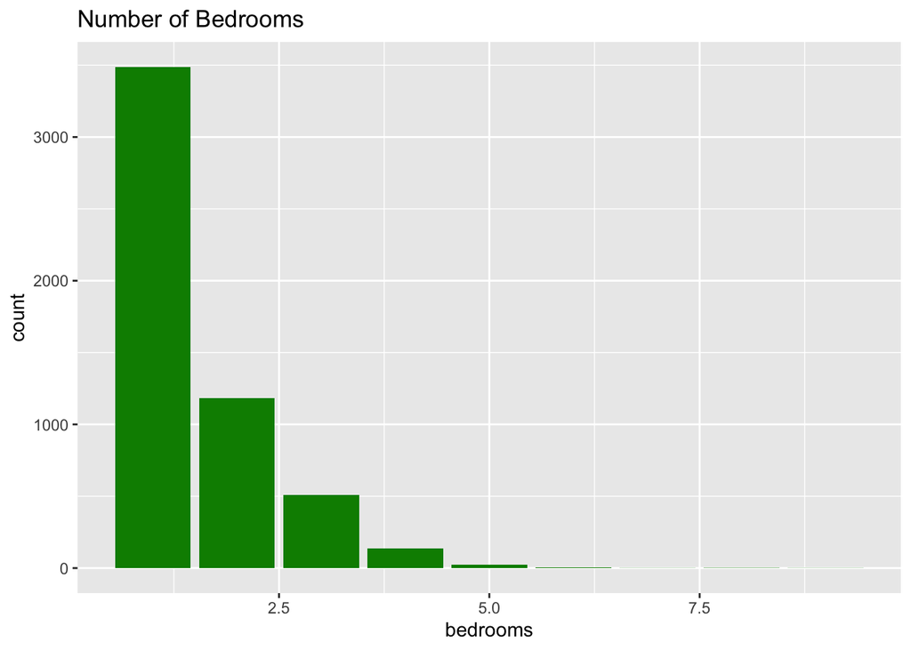

```r
sf_airbnb_data %>%
  ggplot(aes(bedrooms)) +
  geom_bar(fill = "green4") +
  labs(
    title = "Number of Bedrooms"
  )
```

The number of bedrooms will undoubtedly be an important factor in determining the nightly price, most of them seem to be 1, 2, or 3 bedrooms - around 3500, 1250, and 500 respectively, with the rest ranging from 4 to 9, much fewer in the latter ones.

### Count of Each Neighbourhood

Now we will take a look at the distribution of values in the predictor `neighbourhood_cleansed`, and there a few things to be said about this one. There seem to be 36 different neighborhoods accounted for in the city and they vary greatly. For example, the Mission and Downtown/Civic Center have the most units while neighborhoods such as Presidio and Golden Gate Park have very little in comparison. Later on in the recipe creation, we will specify a step to account for the most common neighborhoods, then group the less common ones into an “other” category to make prediction a little more straightforward. One thing I would like to note is that we converted this predictor from a character to a factor with numerous levels, and although this got the job done, I was not able to be as specific as possible by accounting for the median home price in each neighborhood level and order it by that. This is just a side note, but perhaps this would be accounted for better in an unsupervised learning analysis where the neighborhood becomes the response and we could try to predict which neighborhood a unit would be in given its price and other predictors. But on with our analysis.

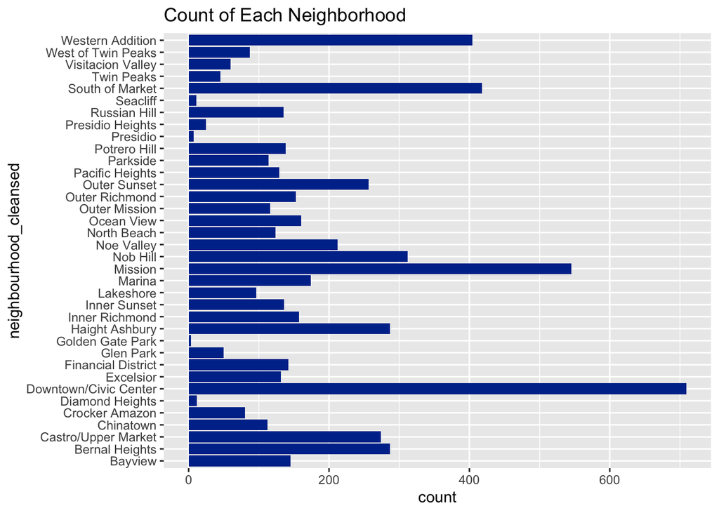

```r
sf_airbnb_data %>%
  ggplot(aes(y = neighbourhood_cleansed)) +
  geom_bar(fill = "#003399") +
  labs(
    title = "Count of Each Neighborhood"
  )
```

### Correlation Plot

We’ll create a correlation plot to explore the overall relationships between all of the continuous, non-missing predictors. This is not the most helpful since we do not have a whole lot of numerical predictors and it seems like there is not a very strong correlation between the others.

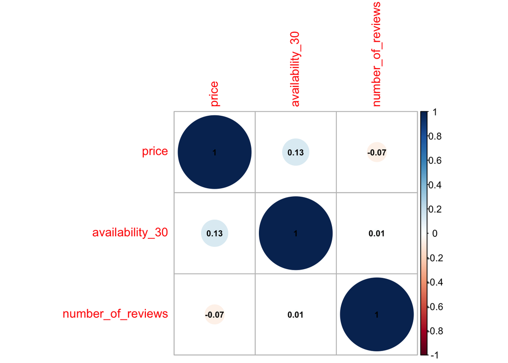

```r
# Selecting only numeric values
airbnb_numeric <- sf_airbnb_data %>%
  select_if(is.numeric)
# Taking out variables with missing values as they will return NA
airbnb_numeric <- airbnb_numeric[, !names(airbnb_numeric) %in% c("host_response_time", "host_response_rate", "host_acceptance_rate", "host_listings_count", "bedrooms", "review_scores_rating", "reviews_per_month")]

# Correlation matrix
airbnb_cor <- cor(airbnb_numeric)

# Visualization of correlation matrix
airbnb_corrplot <- corrplot(airbnb_cor, method = "circle", addCoef.col = 1, number.cex = 0.7)
```

### Relationship Between Price and Number of Bedrooms

Let’s take a look at a seemingly obvious interaction between `price` and the predictor, `bedrooms`, as mentioned before.

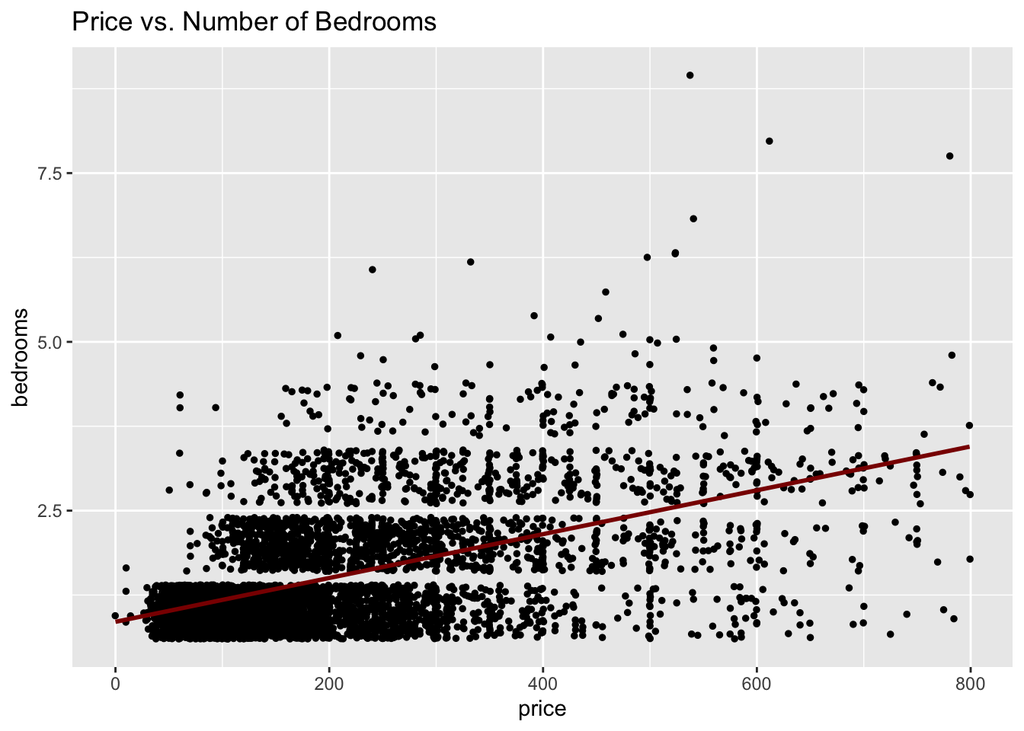

```r
sf_airbnb_data %>%
  ggplot(aes(x=price, y=bedrooms)) +
  geom_jitter(width = 0.5, size = 1) +
  geom_smooth(method = "lm", se =F, col="darkred") +
  labs(title = "Price vs. Number of Bedrooms")
```

Judging by the points clustered all of the place especially on the bottom left, there does not seem to be an extremely strong correlation between `price` and `bedrooms`. However, there does seem to be a moderately positive trend as shown by the red line. Because of this, we now know for sure that the number of bedrooms will affect the nightly price of a unit to a good extent.

# Setting up for the Models

Now we will be fitting models to our data to see if we can predict the nightly price of an SF Airbnb unit based on the predictors we have. However, we first have to set up our data by splitting it into a training and testing set, creating the recipe, and creating folds for k-fold cross validation.

## Data Split

Splitting the data into training and testing sets is important for many reasons. We will use the training split to train the models that we will be testing later on, and leave aside the testing split to run the best model we choose at the end to see how it performs on new data. The proportion we will be using to do this is 70/30, and this will prevent issues such as overfitting because the model is only using 70% of our full dataset to learn. This way, a majority of our data will be used to train, but still have an adequate amount left to test. We’ll also stratify on our response, `price`, to ensure that both the training and the testing data have an equal distribution of it.

```r
# Setting the seed for reproducibility
set.seed(7136)

# Splitting the data (70/30 split, stratify on price)
airbnb_split <- initial_split(sf_airbnb_data, prop = 0.7, strata = price)
airbnb_train <- training(airbnb_split)
airbnb_test <- testing(airbnb_split)
```

By running the following, we’ll verify that the data has been split correctly.

```r
nrow(airbnb_train)/nrow(sf_airbnb_data)
```

```
## [1] 0.6996478
```

```r
nrow(airbnb_test)/nrow(sf_airbnb_data)
```

```
## [1] 0.3003522
```

It seems like the 70/30 split has been properly accounted for.

## Recipe Creation

Using the extremely convenient `tidyverse` and `tidymodels` framework, we’ll be able to create a recipe for all of the models we will be running our data in. We’re using the same predictors and response so this would be an efficient measure, only slightly tweaking it for the polynomial regression model later on. First we will initialize the recipe into a variable using the `recipe` function. Then we will use the `step_impute_linear` to deal with missingness in our predictors, as we’ve mentioned before. There are quite a few predictors with missing observations, with a wide range but not incredibly significant, and that’s okay. For our `neighbourhood_cleansed` predictor we will group the less common neighborhoods into ‘other’. We will dummy categorize the variables that are not continuous, then finally normalize by centering and scaling.

```r
# Creating recipe
airbnb_recipe <- recipe(price ~ host_response_time + host_response_rate + host_acceptance_rate + host_is_superhost + host_verifications + host_identity_verified + neighbourhood_cleansed + bedrooms + availability_30 + number_of_reviews + review_scores_rating + instant_bookable + reviews_per_month, data = airbnb_train) %>%
  # imputing host_response_time
  step_impute_linear(host_response_time, impute_with = imp_vars(neighbourhood_cleansed, availability_30, number_of_reviews, instant_bookable)) %>%
  # imputing host_response_rate
  step_impute_linear(host_response_rate, impute_with = imp_vars(neighbourhood_cleansed, availability_30, number_of_reviews, instant_bookable)) %>%
  # imputing host_acceptance_rate
  step_impute_linear(host_acceptance_rate, impute_with = imp_vars(neighbourhood_cleansed, availability_30, number_of_reviews, instant_bookable)) %>%
  # imputing host_is_superhost
  step_impute_linear(host_is_superhost, impute_with = imp_vars(neighbourhood_cleansed, availability_30, number_of_reviews, instant_bookable)) %>%
  # imputing host_listings_count
  step_impute_linear(host_listings_count, impute_with = imp_vars(neighbourhood_cleansed, availability_30, number_of_reviews, instant_bookable)) %>%
  # imputing host_verifications
  step_impute_linear(host_verifications, impute_with = imp_vars(neighbourhood_cleansed, availability_30, number_of_reviews, instant_bookable)) %>%
  # imputing identity_verified
  step_impute_linear(host_identity_verified, impute_with = imp_vars(neighbourhood_cleansed, availability_30, number_of_reviews, instant_bookable)) %>%
  # imputing bedrooms
  step_impute_linear(bedrooms, impute_with = imp_vars(neighbourhood_cleansed, availability_30, number_of_reviews, instant_bookable)) %>%
  # imputing review_scores_rating
  step_impute_linear(review_scores_rating, impute_with = imp_vars(neighbourhood_cleansed, availability_30, number_of_reviews, instant_bookable)) %>%
  # imputing reviews_per_month
  step_impute_linear(reviews_per_month, impute_with = imp_vars(neighbourhood_cleansed, availability_30, number_of_reviews, instant_bookable)) %>%
  # Only prioritizing the more common neighborhoods
  step_other(neighbourhood_cleansed) %>%
  # dummy coding nominal variables
  step_dummy(host_response_time, host_is_superhost, host_verifications, host_identity_verified, neighbourhood_cleansed, instant_bookable) %>%
  # normalizing
  step_center(all_predictors()) %>%
  step_scale(all_predictors())
```

## K-Fold Cross Validation

We will create 10 folds to conduct a 10-fold stratified cross validation. This is a step beyond our initial split, where R will assign each observation in our training dataset to one of the ten folds. For each fold, a testing set is created consisting of that fold and the remaining 9 folds will be the training set for that fold. Hence the name of this technique, we end up with 10 total folds. It is essentially an extra step to ensure that the dataset is stratified thoroughly.

K-fold cross validation is used because it provides us with a better estimate of the testing accuracy hence better metrics and values rather than simply fitting and testing models on a single training set. This can be seen as a variance reduction technique and fitting on multiple levels instead of one can ensure we achieve this.

We will stratify on the response `price` to make sure the data in each fold is not imbalanced.

```r
# Creating folds
airbnb_folds <- vfold_cv(airbnb_train, v = 10, strata = price)
```

# Model Building

We will now be building our models to test the training data. This requires multiple stages to this which we will walk through step by step. We will use the Root Mean Squared Error (RMSE) as the benchmark metric for model performance at the end, also to determine which we will use for our testing data. The RMSE is one of the most commonly used measures for evaluating the performance of regression models, where a lower RMSE is better since that means the predicted values have a smaller distance from the actual values. Later on, we will be conducting further analysis on the best performing model.

## Fitting the Models

I will be detailing the steps now to fit the various models for our analysis.

We will first set up the model by specifying the functions.

```r
# LINEAR REGRESSION
lm_model <- linear_reg() %>%
  set_engine("lm")

# RIDGE REGRESSION
# Tuning penalty and setting mixture to 0 to specify ridge
ridge_fit <- linear_reg(mixture = 0,
                         penalty = tune()) %>%
  set_mode("regression") %>%
  set_engine("glmnet")

# LASSO REGRESSION
# Tuning penalty and setting mixture to 1 to specify lasso
lasso_fit <- linear_reg(penalty = tune(),
                         mixture = 1) %>%
  set_mode("regression") %>%
  set_engine("glmnet")

# POLYNOMIAL REGRESSION
# Adjusting the recipe because the tuning parameter must be added in the recipe for polynomial regression
# Tuning the degree
poly_adjust <- airbnb_recipe %>%
  step_poly(neighbourhood_cleansed, bedrooms, number_of_reviews, review_scores_rating, reviews_per_month, degree = tune())

poly_fit <- linear_reg() %>%
  set_mode("regression") %>%
  set_engine("lm")

# K NEAREST NEIGHBORS
# Tuning the number of neighbors
knn_fit <- nearest_neighbor(neighbors = tune()) %>%
  set_mode("regression") %>%
  set_engine("kknn")

# ELASTIC NET
# Tuning penalty and mixture
elastic_fit <- linear_reg(penalty = tune(),
                           mixture = tune()) %>%
  set_mode("regression") %>%
  set_engine("glmnet")

# RANDOM FOREST
# Tuning mtry (number of predictors), trees, and min_n (number of minimum values in each node)
rf_fit <- rand_forest(mtry = tune(),
                       trees = tune(),
                       min_n = tune()) %>%
  set_engine("ranger", importance = "impurity") %>%
  set_mode("regression")

# GRADIENT-BOOSTED TREES
# Tuning trees, learn_rate (the learning rate), and min_n
boosted_fit <- boost_tree(trees = tune(),
                           learn_rate = tune(),
                           min_n = tune()) %>%
  set_engine("xgboost") %>%
  set_mode("regression")
```

Then we will set up the workflow for each one, add by adding recipe and respective model to it.

```r
# LINEAR REGRESSION
lm_workflow <- workflow() %>%
  add_recipe(airbnb_recipe) %>%
  add_model(lm_model)

# RIDGE REGRESSION
ridge_workflow <- workflow() %>%
  add_recipe(airbnb_recipe) %>%
  add_model(ridge_fit)

# LASSO REGRESSION
lasso_workflow <- workflow() %>%
  add_recipe(airbnb_recipe) %>%
  add_model(lasso_fit)

# POLYNOMIAL REGRESSION
poly_workflow <- workflow() %>%
  add_recipe(poly_adjust) %>%
  add_model(poly_fit)

# K NEAREST NEIGHBORS
knn_workflow <- workflow() %>%
  add_recipe(airbnb_recipe) %>%
  add_model(knn_fit)

# ELASTIC NET
elastic_workflow <- workflow() %>%
  add_recipe(airbnb_recipe) %>%
  add_model(elastic_fit)

# RANDOM FOREST
rf_workflow <- workflow() %>%
  add_recipe(airbnb_recipe) %>%
  add_model(rf_fit)

# GRADIENT-BOOSTED TREES
boosted_workflow <- workflow() %>%
  add_recipe(airbnb_recipe) %>%
  add_model(boosted_fit)
```

Now we will set up a tuning grid based on the number of parameters to tune, the levels, making sure the range does not exceed the maximum length of the applicable parameter.

```r
# LINEAR REGRESSION
# No grid because no tuning parameters

# RIDGE REGRESSION
penalty_grid <- grid_regular(penalty(range = c(-5,5)), levels = 50)

# LASSO REGRESSION
# Same grid as ridge

# POLYNOMIAL REGRESSION
poly_grid <- grid_regular(degree(range = c(1,5)), levels = 5)

# K NEAREST NEIGHBORS
knn_grid <- grid_regular(neighbors(range = c(1,15)), levels = 5)

# ELASTIC NET
elastic_grid <- grid_regular(penalty(range = c(-5, 5)), mixture(range = c(0,1)), levels = 10)

# RANDOM FOREST
rf_grid <- grid_regular(mtry(range = c(1, 13)), trees(range = c(200,1000)), min_n(range = c(5,20)), levels = 8)

# BOOSTED TREES
boosted_grid <- grid_regular(trees(range = c(5, 200)), learn_rate(range = c(0.01,0.1), trans = identity_trans()), min_n(range = c(40, 60)), levels = 5)
```

In this step, we tune the model using 10-fold cross validation as specified in the previous steps, specify the workflow to the corresponding grid with its parameters.

```r
# LINEAR REGRESSION
# No tuning

# RIDGE REGRESSION
ridge_tuning <- tune_grid(
  ridge_workflow,
  resamples = airbnb_folds,
  grid = penalty_grid
)

# LASSO REGRESSION
lasso_tuning <- tune_grid(
  lasso_workflow,
  resamples = airbnb_folds,
  grid = penalty_grid
)

# POLYNOMIAL REGRESSION
poly_tuning <- tune_grid(
  poly_workflow,
  resamples = airbnb_folds,
  grid = poly_grid
)

# K NEAREST NEIGHBORS
knn_tuning <- tune_grid(
    knn_workflow,
    resamples = airbnb_folds,
    grid = knn_grid
)

# ELASTIC NET
elastic_tuning <- tune_grid(
  elastic_workflow,
  resamples = airbnb_folds,
  grid = elastic_grid
)

# RANDOM FOREST
rf_tuning <- tune_grid(
  rf_workflow,
  resamples = airbnb_folds,
  grid = rf_grid
)

# BOOSTED TREES
boosted_tuning <- tune_grid(
  boosted_workflow,
  resamples = airbnb_folds,
  grid = boosted_grid
)
```

Then we will ollect the metrics of the tuned models using the `collect_metrics` function and extract the lowest RMSE by using the `slice` function.

```r
# LINEAR REGRESSION
# Fitting the linear regression to the folds first (since it had no tuning)
lm_fit <- fit_resamples(lm_workflow, resamples = airbnb_folds)
lm_rmse <- collect_metrics(lm_fit) %>%
  slice(1)

# RIDGE REGRESSION
ridge_rmse <- collect_metrics(ridge_tuning) %>%
  arrange(mean) %>%
  slice(49)

# LASSO REGRESSION
lasso_rmse <- collect_metrics(lasso_tuning) %>%
  arrange(mean) %>%
  slice(35)

# POLYNOMIAL REGRESSION
poly_rmse <- collect_metrics(poly_tuning) %>%
  arrange(mean) %>%
  slice(6)

# K NEAREST NEIGHBORS
knn_rmse <- collect_metrics(knn_tuning) %>%
  arrange(mean) %>%
  slice(6)

# ELASTIC NET
elastic_rmse <- collect_metrics(elastic_tuning) %>%
  arrange(mean) %>%
  slice(73)

# RANDOM FOREST
rf_rmse <- collect_metrics(rf_tuning) %>%
  arrange(mean) %>%
  slice(513)

# BOOSTED TREES
boosted_rmse <- collect_metrics(boosted_tuning) %>%
  arrange(mean) %>%
  slice(126)
```

# Model Results

```r
models_rmse_comparison <- tibble(Model = c("Linear Regression", "Ridge Regression", "Lasso Regression", "Polynomial Regression", "K Nearest Neighbors", "Elastic Net", "Random Forest", "Boosted Trees"), RMSE = c(lm_rmse$mean, ridge_rmse$mean, lasso_rmse$mean, poly_rmse$mean, knn_rmse$mean, elastic_rmse$mean, rf_rmse$mean, boosted_rmse$mean))
models_rmse_comparison
```

[output not shown]

We’ll now use the autoplot function on some of our best performing models to see the effect of each of the tuned parameters by observing the RMSE for each, looking for a lower value.

### Random Forest Autoplot

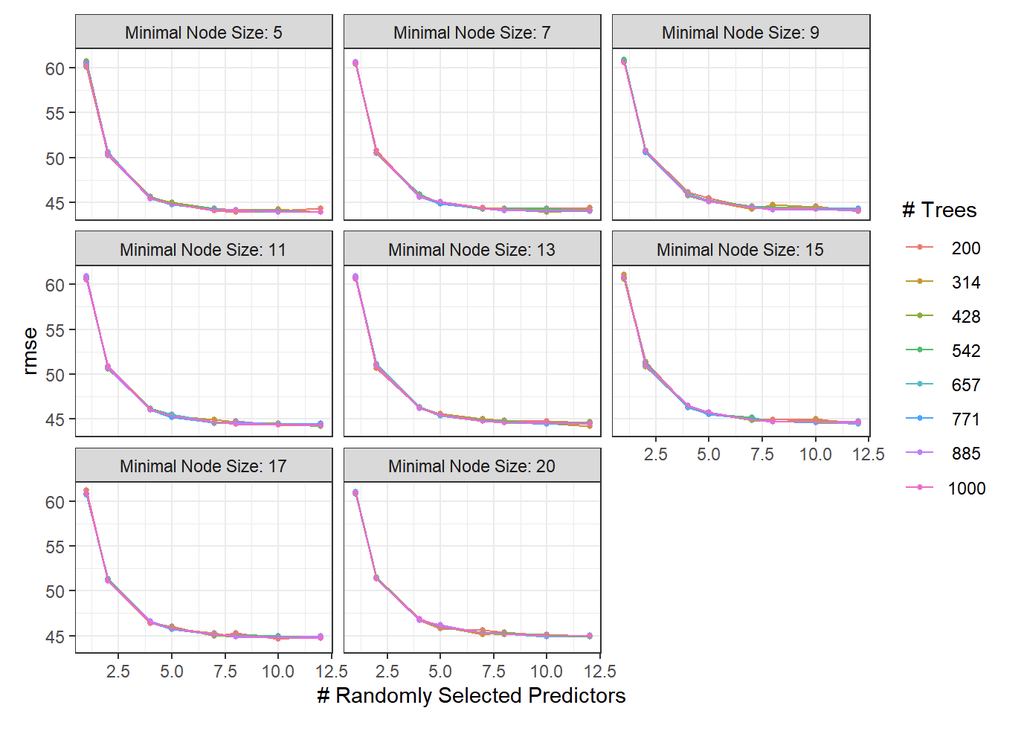

```r
autoplot(rf_tuning, metric = 'rmse')
```

### Boosted Trees Autoplot

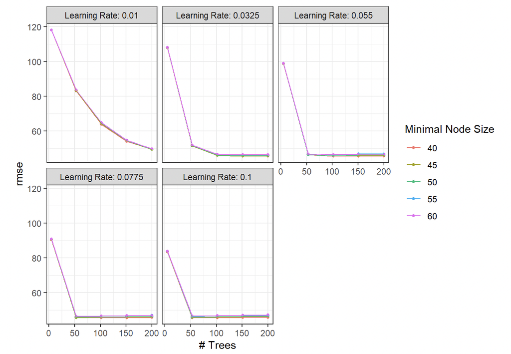

```r
autoplot(boosted_tuning, metric = 'rmse')
```